# COMM 187 Coding Lab 1 Summer 2024

Hannah Overbye-Thompson

2024-07-02

# Introduction

Welcome to the first Coding Lab for COMM 187: Data Science in Communication Research!

Today’s lesson plan:

Familiarize yourself with this coding platform – Jupyterhub Learn a few basic commands in R Submit a test assignment using Gradescope(?)

Many of our lessons are inspired by R for Data Science feel free to check it out here:

https://r4ds.had.co.nz/introduction.html

This will probably be a bit redundant from the DataCamp class, but it is good to really know the basics!

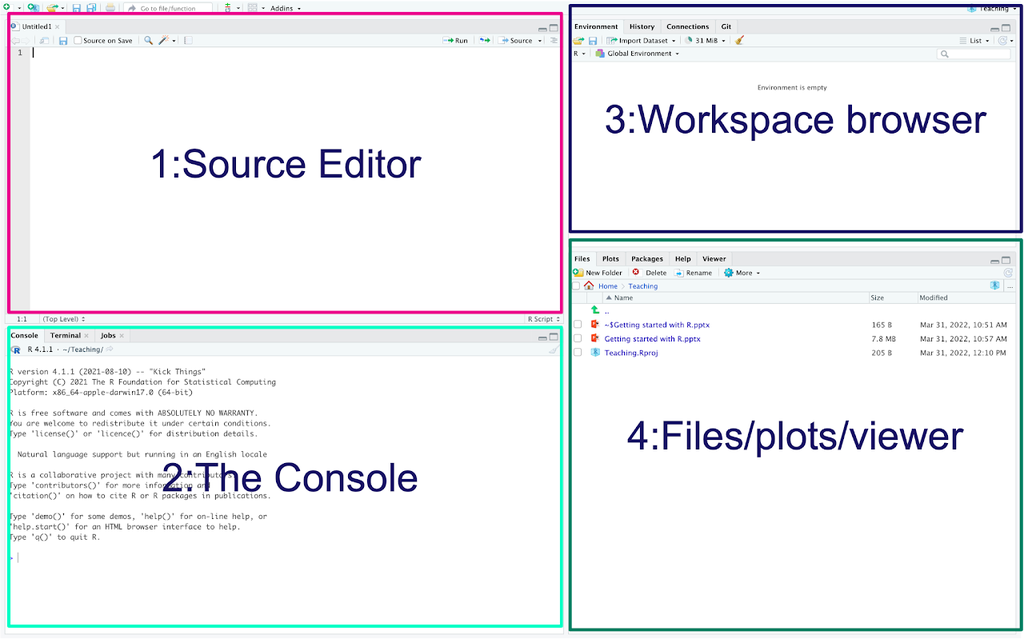

**R Studio has four main panels:**

1. **The source editor**

The source editor is where you write most (if not all) of your code. You can have multiple tabs for the source editor for different .R and markdown files

2. **The Console**

If you type code here it will be executed immediately and not saved. This is normally only used for short commands.

Mainly, you will use the console to see the output of your code

3. **Workspace Browser**

Here you find your “environment” which is how you can see all of your objects

4. **Files/plots/viewer/help**

There are many different tabs here. The most important one is the plots tab, this is where any plots you create will be displayed

Additionally, you have the files tab which shows you the files in your current working directory

# **Basic Functionality and a Brief Introduction to Object-Oriented Programming**

**Basic Functionality**

Although R is frequently used to accomplish amazing feats of statistical analysis and data visualization, when starting out it is best to learn to use R as though it were a fancy calculator.

R can do everything that a calculator can do:

```r
6 + 2 # it can preform addition
```

```
## [1] 8
```

```r
5 - 3 #  subtraction
```

```
## [1] 2
```

```r
6 * 2 # multiplication
```

```
## [1] 12
```

```r
3/4 # division
```

```
## [1] 0.75
```

```r
6**2 # and exponentiation
```

```
## [1] 36
```

Furthermore, it has the ability to place the results of these calculations into an “object”, allowing you to save the value for later.

```r
x = 6 + 3
print(x)
```

```
## [1] 9
```

### Object Oriented Programming

These objects are extremely important as R is an object oriented programming language. In short, object-oriented programming languages provide a way to store data within objects, by encapsulating data and functions that operate on that data together. This allows for a clear and organized structure for the code, making it easier to understand, maintain, and reuse.

#### R has many arithmetic, comparison, and logical operators

**Arithmetic Operators**

- `+` : Addition
- `-` : Subtraction
- `*` : Multiplication
- `/` : Division
- `^` or `**` : Exponentiation
- `%%` : Modulus (remainder from division)
- `%/%` : Integer Division

```r
# Examples:
a <- 10
b <- 3

a + b # Addition: 13
```

```
## [1] 13
```

```r
a - b # Subtraction: 7
```

```
## [1] 7
```

```r
a * b # Multiplication: 30
```

```
## [1] 30
```

```r
a / b # Division: 3.3333
```

```
## [1] 3.333333
```

```r
a ^ b # Exponentiation: 1000
```

```
## [1] 1000
```

```r
a %% b # Modulus: 1
```

```
## [1] 1
```

```r
a %/% b # Integer Division: 3
```

```
## [1] 3
```

**Comparison Operators**

- `==` : Equal to
- `!=` : Not equal to
- `>` : Greater than
- `<` : Less than
- `>=` : Greater than or equal to
- `<=` : Less than or equal to

```r
# Examples:
a <- 10
b <- 3

a == b  # Equal to: FALSE
```

```
## [1] FALSE
```

```r
a != b  # Not equal to: TRUE
```

```
## [1] TRUE
```

```r
a > b   # Greater than: TRUE
```

```
## [1] TRUE
```

```r
a < b   # Less than: FALSE
```

```
## [1] FALSE
```

```r
a >= b  # Greater than or equal to: TRUE
```

```
## [1] TRUE
```

```r
a <= b  # Less than or equal to: FALSE
```

```
## [1] FALSE
```

**Logical Operators**

- `&` : Element-wise AND
- `|` : Element-wise OR
- `!` : NOT
- `&&` : Logical AND
- `||` : Logical OR

  ```r
  x <- TRUE
  y <- FALSE

  x & y   # Element-wise AND: FALSE
  ```

  ```
  ## [1] FALSE
  ```

  ```r
  x | y   # Element-wise OR: TRUE
  ```

  ```
  ## [1] TRUE
  ```

  ```r
  !x      # NOT: FALSE
  ```

  ```
  ## [1] FALSE
  ```

  ```r
  x && y  # Logical AND: FALSE
  ```

  ```
  ## [1] FALSE
  ```

  ```r
  x || y  # Logical OR: TRUE
  ```

  ```
  ## [1] TRUE
  ```

# **R Basic Data Types & Structures**

**Data Types**

**1.) Logical:** TRUE, FALSE

- Also denoted T or F logical data types can be used in conditional statements and can be used to filter or index data in a data frame or vector

```r
x <- 5
y <- 3

x > y # returns TRUE
```

```
## [1] TRUE
```

**2.) Double:** 12.333, 40.3913, 1.0

- In R a double is one of the most common data types you will encounter. It is used to denote any real decimal number, also known as a **float**.
- Similarly, the **numeric** data type also denotes any number. The **integer** data type denotes any non-floating point integer.
- Mostly, however, R will denote any numeric value as a double

```r
x <- 5 # an integer
y <- 3.14 # a double or floating point number
z <- 427 # another integer

typeof(x)
```

```
## [1] "double"
```

**3.) Character:** “Hello”, “1”, “FALSE”

- The character data type is used to represent text or strings of data and is enclosed in either double or single quotes.
- It is important to note that **if you place logical or a numeric data type in quotes, it becomes a character**

```r
x <- "Hello World!"
y <- 'I love coffee'
z <- "R is my favorite letter"

typeof(x)
```

```
## [1] "character"
```

**Data Structures**

**Vectors**

A vector is a list of the same type of data type. You can use the c() function to create a vector.

```r
numbers <- c(1, 2, 3, 4, 5)
letters <- c("a", "b", "c")
logical_values <- c(TRUE, FALSE, TRUE)
```

**Matrices**

A matrix in R is a 2-dimensional data structure that contains elements of the same data type (e.g. numeric, character, logical).

```r
# using the character type
coffee_types <- c("Espresso", "Latte", "Cappuccino", "Macchiato")
coffee_matrix_1 <- matrix(coffee_types[1:2], ncol=2, byrow=TRUE)
coffee_matrix_2 <- matrix(coffee_types[3:4], ncol=2, byrow=TRUE)
coffee_matrix <- rbind(coffee_matrix_1, coffee_matrix_2)
coffee_matrix
```

```
##      [,1]         [,2]
## [1,] "Espresso"   "Latte"
## [2,] "Cappuccino" "Macchiato"
```

```r
# using numeric type
coffee_prices <- c(2.50, 3.50, 4.00, 4.50)
price_matrix_1 <- matrix(coffee_prices[1:2], ncol=2, byrow=TRUE)
price_matrix_2 <- matrix(coffee_prices[3:4], ncol=2, byrow=TRUE)
price_matrix <- rbind(price_matrix_1, price_matrix_2)
price_matrix
```

```
##      [,1] [,2]
## [1,]  2.5  3.5
## [2,]  4.0  4.5
```

```r
# using logical type
coffee_matrix <- matrix(c(TRUE, FALSE, TRUE, TRUE), ncol=4, byrow=TRUE)
coffee_matrix
```

```
##      [,1]  [,2] [,3] [,4]
## [1,] TRUE FALSE TRUE TRUE
```

```r
# You can also give names to the rows and columns of your matrix!
colnames(coffee_matrix) <- coffee_types
rownames(coffee_matrix) <- c("Avalible")

coffee_matrix
```

```
##          Espresso Latte Cappuccino Macchiato
## Avalible     TRUE FALSE       TRUE      TRUE
```

**A quick note about notation...**

Matrices in R follow the format where the row number is listed first, followed by the column number

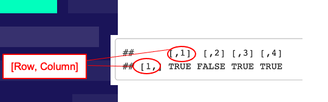

**Data Frames**

A data frame in R is a two-dimensional data structure that is used to store data, with rows representing observations and columns representing variables. It can handle a variety of data types including numeric, character, and logical values, and is one of the most common types of data structures in social science research. A few notes about data frames

1. They are similar to matrices in that they have rows and columns, but unlike matrices, data frames can have different data types for each column
2. They can be created from a variety of sources, such as CSV files, spreadsheets, or databases.

```r
coffee_types <- c("Espresso", "Latte", "Cappuccino", "Macchiato")
coffee_prices <- c(2.50, 3.50, 4.00, 4.50)
coffee_availability <- c(TRUE, FALSE, TRUE, TRUE)

coffee_dataframe <- as.data.frame(cbind(coffee_types, coffee_prices, coffee_availability))
coffee_dataframe
```

```
##   coffee_types coffee_prices coffee_availability
## 1     Espresso           2.5                TRUE
## 2        Latte           3.5               FALSE
## 3   Cappuccino             4                TRUE
## 4    Macchiato           4.5                TRUE
```

# **Functions**

Understanding functions (what they are, how to use them, how to make them) is one of the most important aspects of learning R.

**What are Functions?!**

Functions in R are self-contained blocks of code that perform specific tasks, and are designed to accept inputs and return outputs. We have already used quite a few functions today. Some examples include:

- c()
- typeof()
- as.data.frame()
- matrix()

Functions accept an input, and produce an output.

1. Inputs: Functions accept inputs, also known as arguments, which can be used to control the behavior of the function
2. Functions return outputs, which can be used in other parts of the code or assigned to variables.

```r
# for example, the function sum takes a numeric input,
# and produces a sum of the numbers as its output
sum(4,5,19)
```

```
## [1] 28
```

**How do you use functions?**

To use a function, you have to call it. All this means is that you type in the name of the function followed by parentheses (see sum() example above). Next, you type in the arguments that the function asks for. If you want to get information on a specific function, type help(function name). For example, if I wanted help understanding the sum function, I would type:

This results in a description of the function and it’s usage in the files/plots/viewer/help panel of Rstudio

```r
help(sum)
```

R has many functions, so many that I couldn’t list them all here. However, here are some of the more useful ones:

1. c() - Concatenates elements into a vector.
2. mean() - Calculates the mean of a vector of numbers.
3. sum() - Calculates the sum of a vector of numbers.
4. sort() - Sorts a vector of numbers in ascending or descending order.
5. unique() - Returns unique values of a vector.
6. max() - Returns the maximum value of a vector.
7. min() - Returns the minimum value of a vector.
8. sqrt() - Returns the square root of a number.
9. round() - Rounds a number to a specified number of decimal places.
10. head() - Returns the first n rows of a data frame or matrix.
11. tail() - Returns the last n rows of a data frame or matrix.
12. str()- Displays the structure of an object in R.
13. table() - Creates a contingency table of the counts of unique values.

**Writing Functions**

Even though there are many many functions in R, sometimes you may want to write your own function. Knowing how to do this is important as 1.) It allows you to understand how R works a little bit better, and 2.) Gives you the ability to create functions for your specific needs.

Even though writing a function sounds rather intimidating, actually doing it is pretty simple. Here is an example:

```r
coffee_calculator <- function(coffee_price, cups_needed) {
  cost <- coffee_price * cups_needed
  return(cost)
}

coffee_calculator(2, 5)
```

```
## [1] 10
```

### Practice!

Assign the values 15 and 20 to the variables `x` and `y` respectively. Write expressions using comparison operators to check the following:

1. Is `x` equal to `y`? 2. Is `x` not equal to `y`? 3. Is `x` greater than `y`? 4. Is `x` less than `y`? 5. Is `x` greater than or equal to `y`? 6. Is `x` less than or equal to `y`?

```r
# Your code here: ...
```

2. Calculate the mean of the vector c(2, 4, 6, 8, 10)

```r
# Your code here: ...
```

3. Create a character vector named `fruits` with the values “apple”, “banana”, “cherry”. Print the second element of the `fruits` vector.

```r
# Your code here: ...
```

4. Create a matrix named `matrix_example` with 3 rows and 2 columns, filled with numbers from 1 to 6. Print the matrix.

```r
# Your code here: ...
```

5. Challenge! Create a function that will calculate the mean (average!) of any vector (Hint, use the sum () and len() functions)

```r
# Your code here: ...
```

6. Challenge 2! Write a custom function named `fahrenheit_to_celsius` that converts a temperature from Fahrenheit to Celsius. Use the function to convert 98.6 degrees Fahrenheit to Celsius and print the result.

```r
# Your code here: ...
```